# projekt_ML_Insurance

- Show All Code
- Hide All Code
- View Source

Author

Szymon Jarmołowski

# 1 Wstęp

Analizowany jest znany zbiór danych o kosztach ubezpieczenia medycznego (pierwotnie opracowany przez Machine Learning with R). Zawiera on 1338 obserwacji osób wraz z informacjami demograficznymi, zdrowotnymi, stylu życia, a także ich rocznymi składkami na ubezpieczenie medyczne. Zbiór danych obejmuje zmienne takie jak wiek, płeć, wskaźnik masy ciała (BMI), palenie papierosów, liczba dzieci oraz region zamieszkania w Stanach Zjednoczonych (północny wschód, północny zachód, południowy wschód, południowy zachód). Celem jest zbadanie czynników wpływających na koszty leczenia i zbudowanie modeli predykcyjnych do szacowania składek ubezpieczeniowych.

# 2 Czyszczenie danych

**Ładowanie potrzebnych bibliotek**

```r
library(tidymodels)
library(parsnip)
library(readr)
library(broom.mixed)
library(dotwhisker)
library(ggplot2)
library(ggcorrplot)
library(GGally)
library(moments)
library(workflowsets)
library(dials)
library(dplyr)
library(purrr)
library(tidyr)
library(rsample)
library(tune)
library(splines)
library(rpart)
library(rpart.plot)
```

**Załadowanie danych**

```r
df = read.csv("insurance.csv")
print(head(df))
```

```
  age    sex    bmi children smoker    region   charges
1  19 female 27.900        0    yes southwest 16884.924
2  18   male 33.770        1     no southeast  1725.552
3  28   male 33.000        3     no southeast  4449.462
4  33   male 22.705        0     no northwest 21984.471
5  32   male 28.880        0     no northwest  3866.855
6  31 female 25.740        0     no southeast  3756.622
```

**Czyszczenie danych**

```r
# Sprawdzenie brakujących danych
df |> is.na() |> as.tibble()|>  summarise_all(sum)
```

```
# A tibble: 1 × 7
    age   sex   bmi children smoker region charges
  <int> <int> <int>    <int>  <int>  <int>   <int>
1     0     0     0        0      0      0       0
```

**Czyszczenie danych**

```r
# Usunięcie duplikatów
df[duplicated(df),]
```

```
    age  sex   bmi children smoker    region  charges
582  19 male 30.59        0     no northwest 1639.563
```

**Czyszczenie danych**

```r
df <- df |> unique()
```

**Podsumowanie danych**

```r
df |> summary()
```

```
      age            sex                 bmi           children
 Min.   :18.00   Length:1337        Min.   :15.96   Min.   :0.000
 1st Qu.:27.00   Class :character   1st Qu.:26.29   1st Qu.:0.000
 Median :39.00   Mode  :character   Median :30.40   Median :1.000
 Mean   :39.22                      Mean   :30.66   Mean   :1.096
 3rd Qu.:51.00                      3rd Qu.:34.70   3rd Qu.:2.000
 Max.   :64.00                      Max.   :53.13   Max.   :5.000
    smoker             region             charges
 Length:1337        Length:1337        Min.   : 1122
 Class :character   Class :character   1st Qu.: 4746
 Mode  :character   Mode  :character   Median : 9386
                                       Mean   :13279
                                       3rd Qu.:16658
                                       Max.   :63770
```

W zbiorze danych nie znaleziono brakujących danych. Usunięto natomiast jeden duplikat.

Badane zmienne:

- age – wiek osoby, zawiera obserwacje z przedziału 18–64 ze średnim wiekiem pacjenta ~39.
- sex – płeć, zmienna jakościowa.
- bmi – stosunek masy do wzrostu, występują zarówno niskie obserwacje 15.96 jak i bardzo wysokie 53.13. W dalszej części pracy wartości te zostaną sprawdzone.
- chlidren - ilość dzieci z wartościami od 0 do 5.
- smoker - zmienna wskazująca czy osoba jest paląca.
- region - cześć USA: northeast, northwest, southeast oraz southwest.
- charges - koszt ubezpieczenia. Zmienna objaśniana.

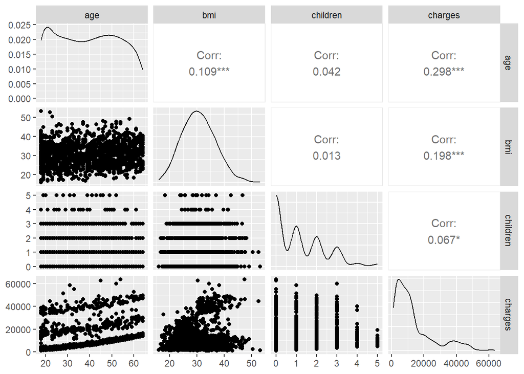

```r
# Zmienne numeryczne
df |> select(where(is.numeric)) |> ggpairs()
```

Nie występuje wysoka korelacja między zmiennymi objaśniającymi. W zbiorze danych przeważają młodzi ludzi ludzie, chociaż liczba obserwacji między 20 a 50 rokiem życia jestw zględnie ta sama. Ludzi po 60 roku życia jest wyraźnie mniej. W przypadku BMI rozkład jest prawostronny, co wskazuje na występowania zmiennych odstających w górnych przedziałach. Nie obserwuje się zależności między BMI a wiekiem. Obserwacje z wysokim BMI (>50) występują dla osób poniżej 30 roku życia. W przypadku ilości dzieci dominują obserwacje z 0 ilością dzieci, stopniowo zmniejszając się wraz z zwiększaniem liczby dzieci. Nie obserwuje się zależności między liczbą dzieci, a wiekiem oraz BMI. Rozkład kosztu ubezpieczenia jest silnie prawostronny. Obserwuje się liniowy wzrost kosztu wraz z wzrostem wieku. Natomiast wiek nie jest jedyną determinantą - istnieje wiele obserwacji które formują równoległe liniowe linie wyżej co sugeruje istnienie dodatkowych czynników. Występuje dodatnia korelacja między wzrostem BMI a opłatami. Osoby z od 0 do 3 dzieci mają zarówno niskie jak i wysokie opłaty, natomiast dla 4 i 5 dzieci obserwuje się głównie niskie koszta ubezpieczenia.

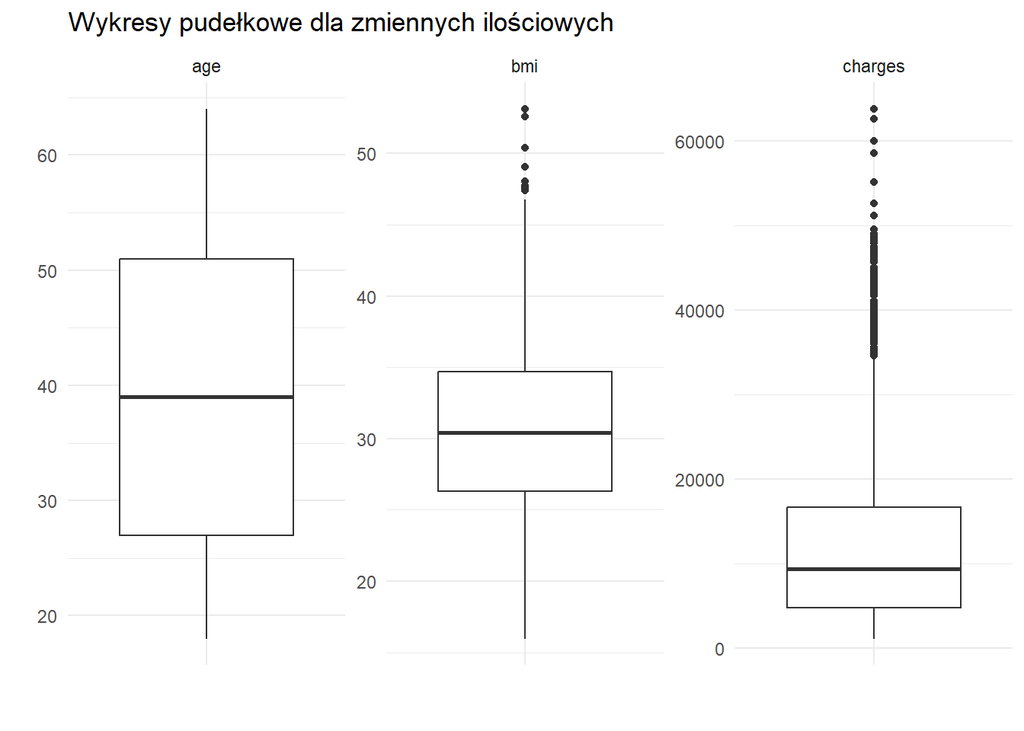

```r
df |>
  select(age, bmi, charges) |>
  pivot_longer(everything()) |>
  ggplot(aes(x = "", y = value)) +
  geom_boxplot() +
  facet_wrap(~name, scales = "free_y") +
  theme_minimal() +
  labs(title = "Wykresy pudełkowe dla zmiennych ilościowych", x = "", y = "")
```

Obserwuje się kilka wartości odstających dla BMI (>45) oraz wiele wartości powyżej górnego wąsa dla opłat.

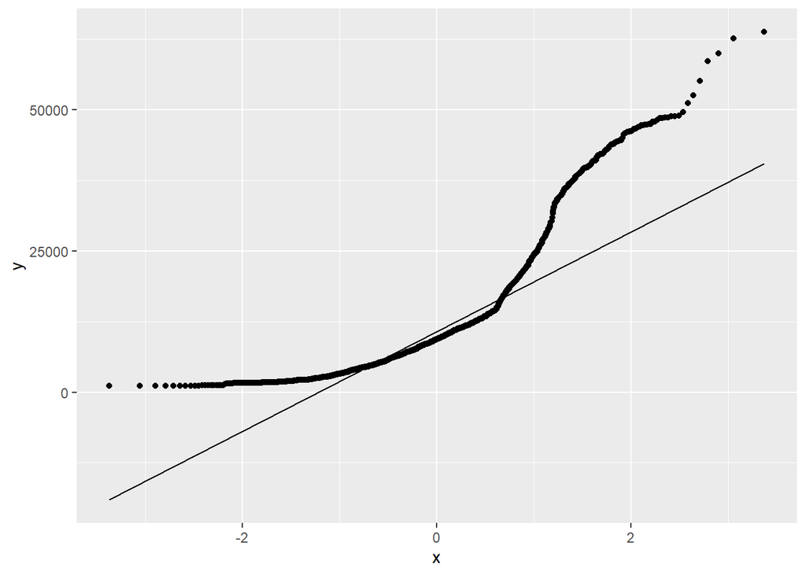

```r
df |> ggplot(aes(sample = charges)) + stat_qq() + stat_qq_line()
```

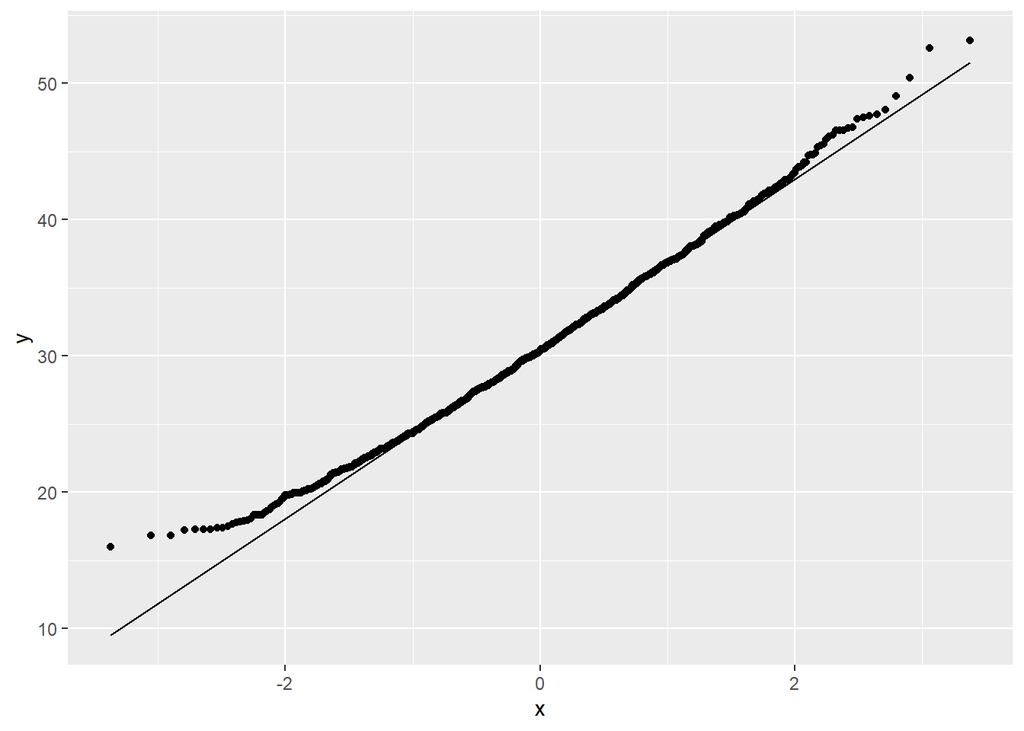

```r
df |> ggplot(aes(sample = bmi)) + stat_qq() + stat_qq_line()
```

[output not shown]

[output not shown]

```r
df$charges_log = log(df$charges)
cat("Skośność rozkładu opłat po transformacji logarytmicznej", skewness(df$charges_log))
```

```
Skośność rozkładu opłat po transformacji logarytmicznej -0.08973781
```

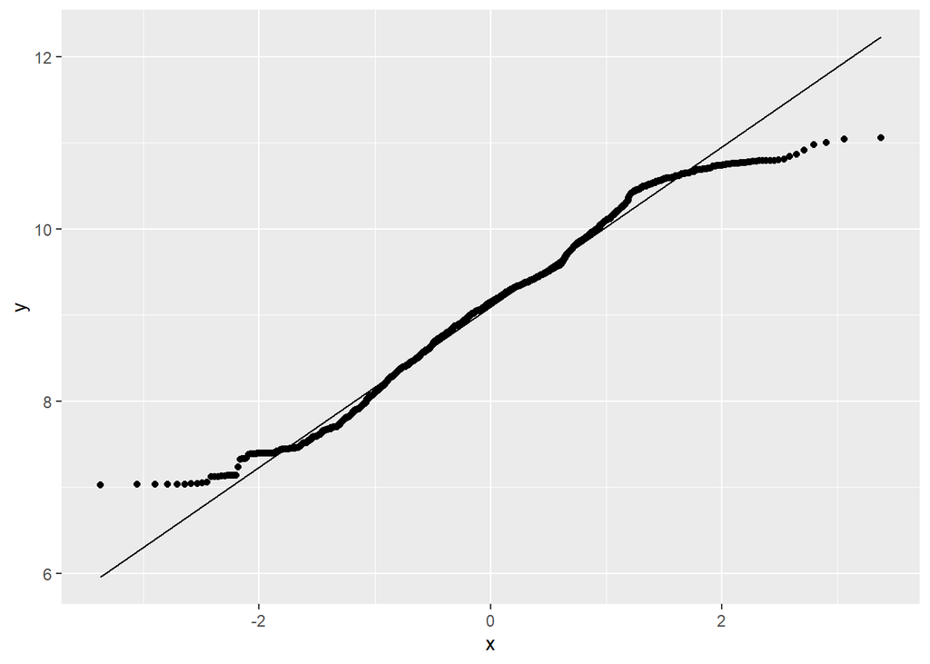

```r
df |> ggplot(aes(sample = charges_log)) + stat_qq() + stat_qq_line()
```

Po transformacji logarytmicznej rozkład jest o wiele bliższy normalnemu. Występuję więcej wartości odstających po lewej stronie rozkładu oraz mniej po prawej w porównaniu do rozkładu normalnego.

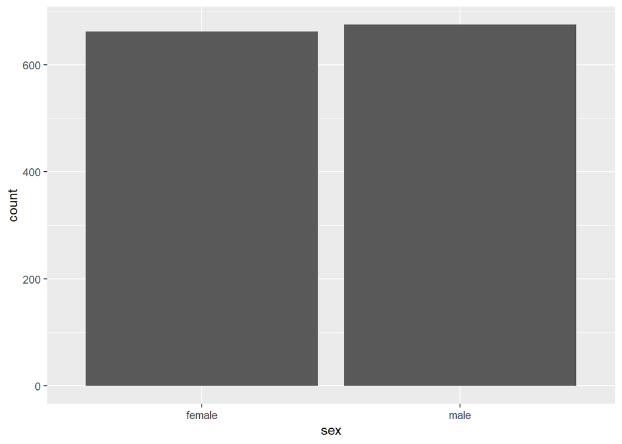

```r
ggplot(data = df, aes(x = sex)) + geom_bar()
```

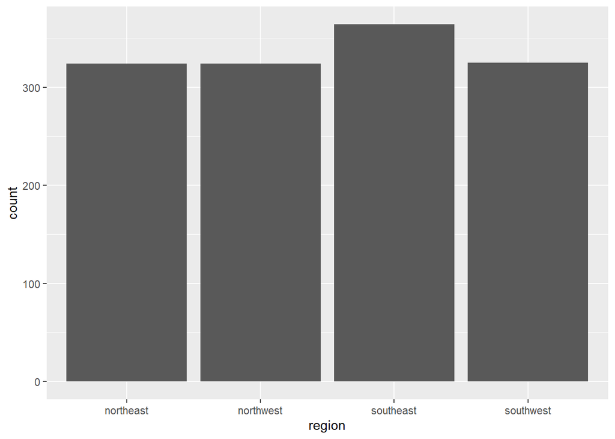

```r
ggplot(data = df, aes(x = region)) + geom_bar()
```

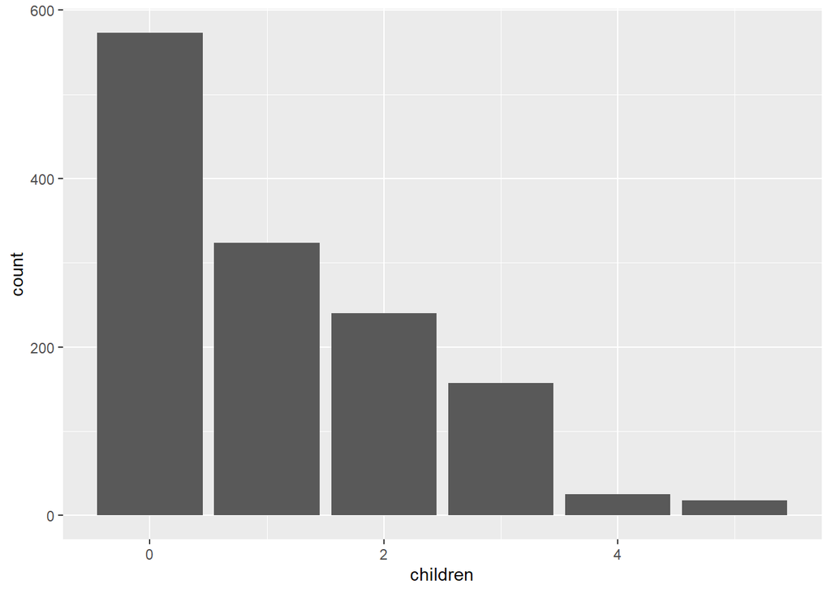

```r
ggplot(data = df, aes(x=children)) + geom_bar()
```

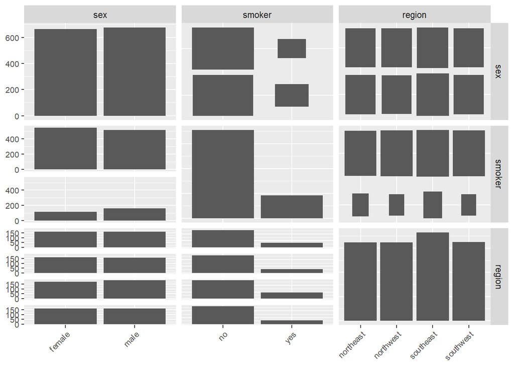

```r
p <-df |> select(sex,smoker,region) |> ggpairs() +
  theme(axis.text.x = element_text(angle = 45, hjust = 1, size = 8)) +
  theme(axis.text.y = element_text(angle = 0, hjust = 1, size = 8))

print(p, progress=FALSE)
```

Ilość mężczyzn do ilości kobiet jest podobna. Większość palaczy jest wśród mężczyzn. Większość osób nie pali. Nie obserwuje się zależności między zmiennymi objaśnianymi a regionem.

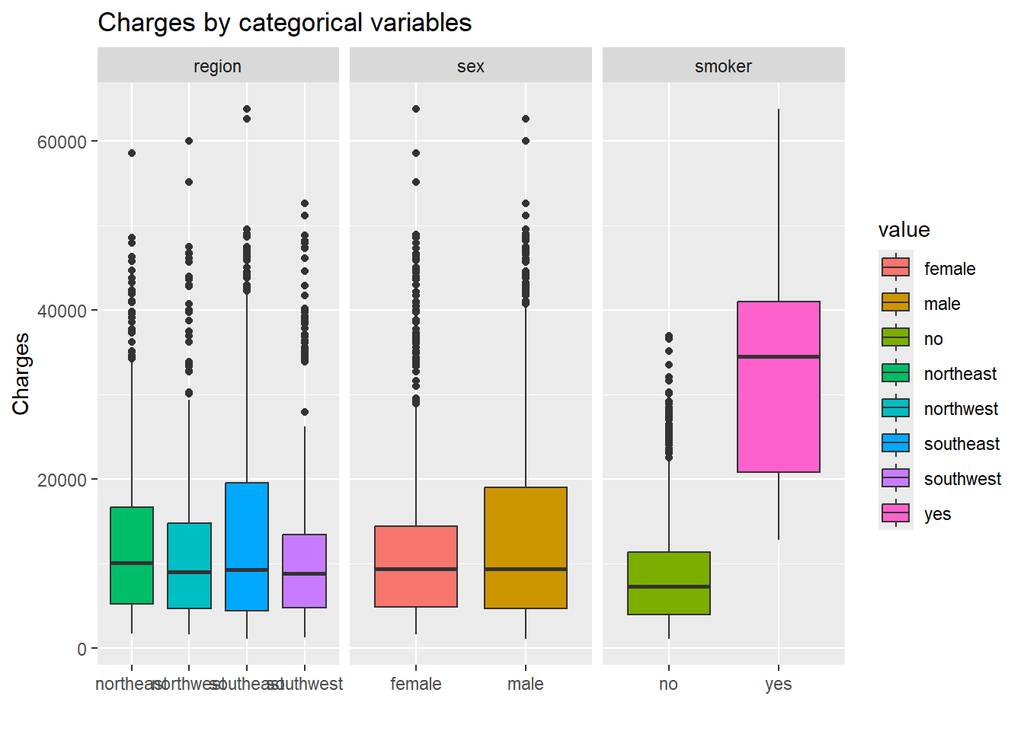

```r
df |> select(region, sex, smoker, charges) |>
  pivot_longer(cols = c(region, sex, smoker)) |>
  ggplot(aes(x=value, y=charges, fill = value)) +
  geom_boxplot() +
  facet_wrap(~ name, scales = "free_x") +
  labs(title = "Charges by categorical variables", x = "", y = "Charges")
```

W przypadku zmiennych kategorycznych obserwuje się znacząco większe koszty ubezpieczenia dla osób palących. W przypadku niepalących media jest znacznie niżej za to występuje wiele wartości odstających ponad górny wąs, co może oznaczać, że istnieje dodatkowy czynnik, który zwiększa koszt ubezpieczenia. Media opłat dla mężczyzn oraz kobieta jest ta sama, za to górny kwartyl dla mężczyzn jest znacznie wyżej. Oznacza to, że wsród mężczyzn koszt jest mniej skupiony wokół mediany i ma tendencje do obserwacji z wyższym kosztem. Dla regiony koszta wyglądają bardzo podobnie, najwyższy wąs pojawia się dla południowego wschodu.

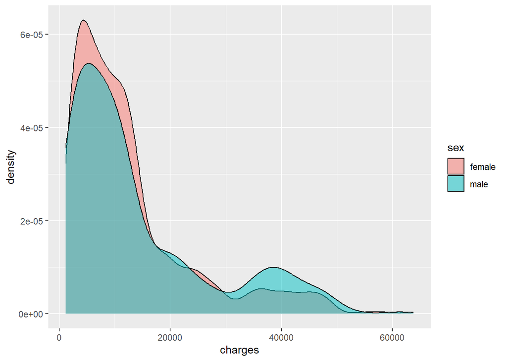

```r
df |> ggplot(aes(x=charges, fill = sex)) + geom_density(alpha = 0.5)
```

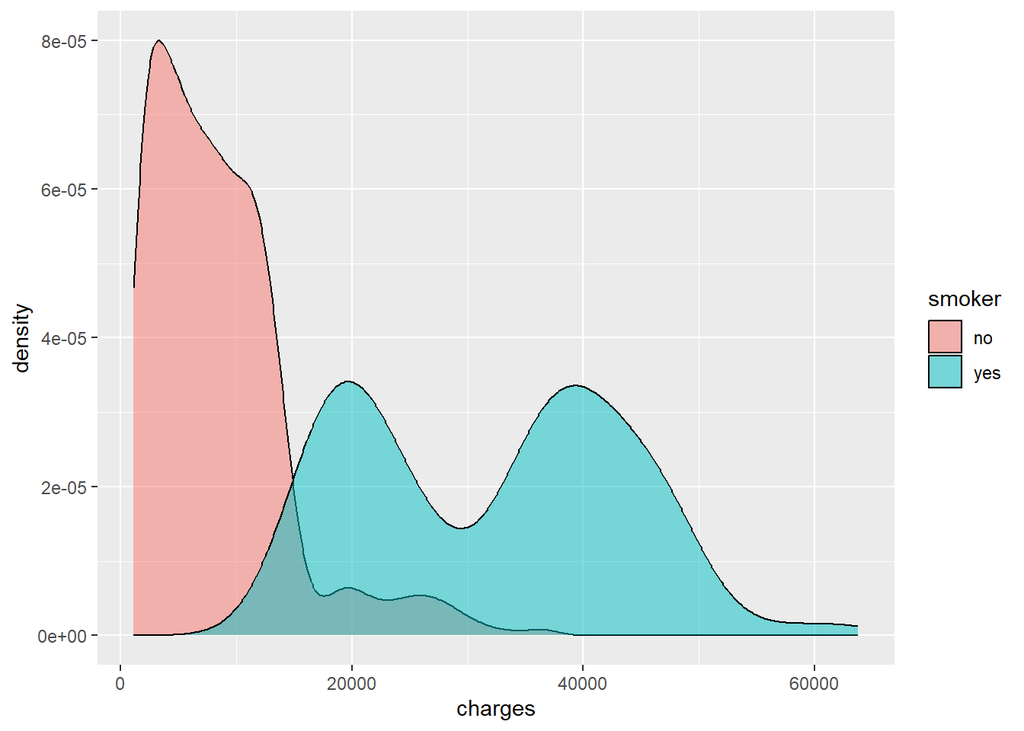

```r
df |> ggplot(aes(x=charges, fill = smoker)) + geom_density(alpha = 0.5)
```

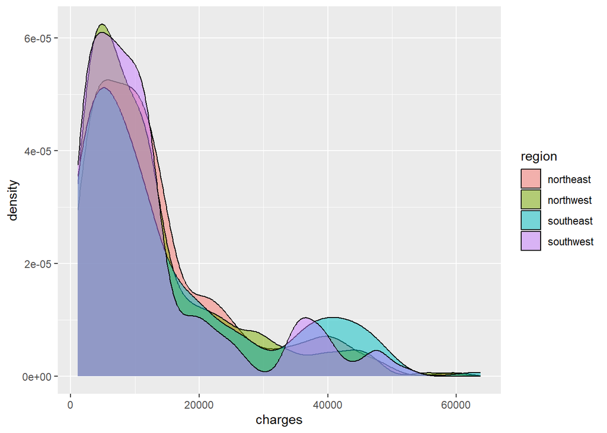

```r
df |> ggplot(aes(x=charges, fill = region)) + geom_density(alpha = 0.5)
```

Z powyższych wykresów wynika, że palące osoby mają znacznie większą składke ubezpieczniową oraz kumulują się w okolicy 20000 oraz 40000.

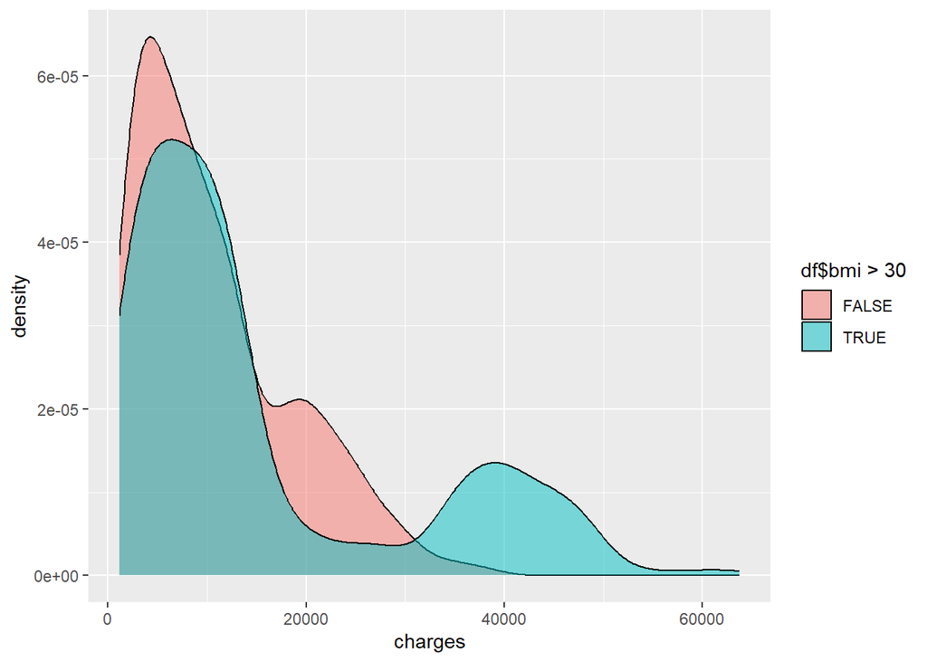

```r
df |> ggplot(aes(x=charges, fill = df$bmi >30)) + geom_density(alpha = 0.5)
```

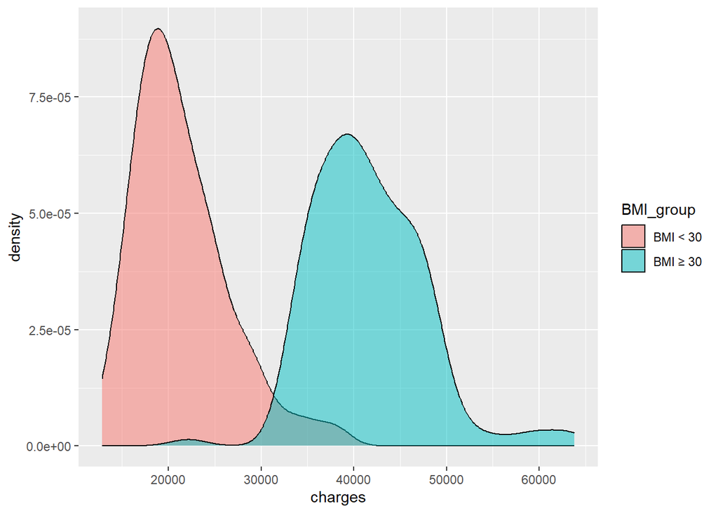

```r
df %>%
  filter(smoker == "yes") %>%
  mutate(BMI_group = ifelse(bmi < 30, "BMI < 30", "BMI ≥ 30")) %>%
  ggplot(aes(x = charges, fill = BMI_group)) +
  geom_density(alpha = 0.5)
```

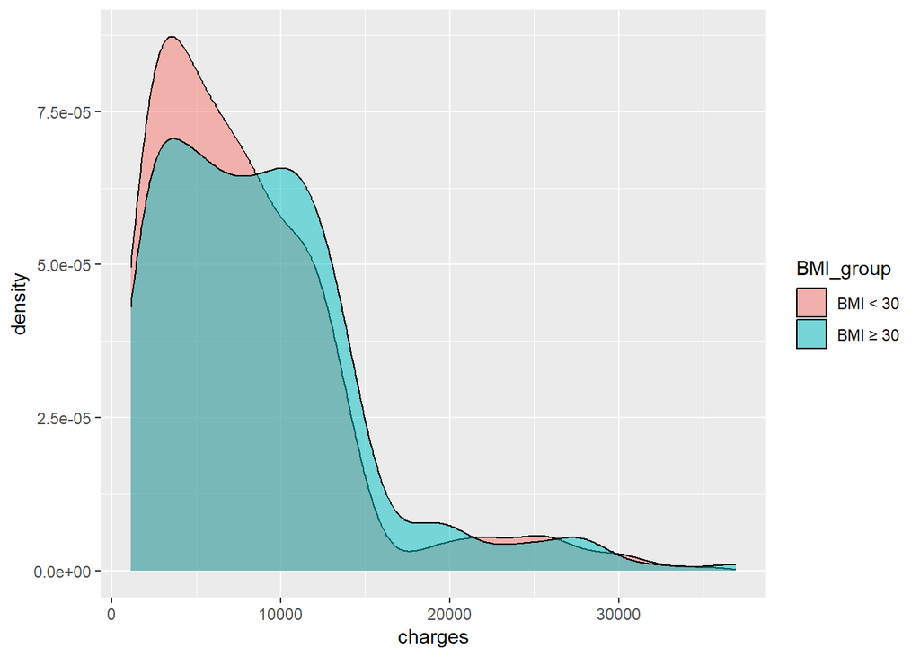

```r
df %>%
  filter(smoker == "no") %>%
  mutate(BMI_group = ifelse(bmi < 30, "BMI < 30", "BMI ≥ 30")) %>%
  ggplot(aes(x = charges, fill = BMI_group)) +
  geom_density(alpha = 0.5)
```

Palące osoby z BMI powyżej 30 mają średni koszt w okolicy 40000, a poniżej 30 w okolicy 20000. W przypadku osób niepalących BMI nie ma dużego wpływu na koszt ubezpieczenia.

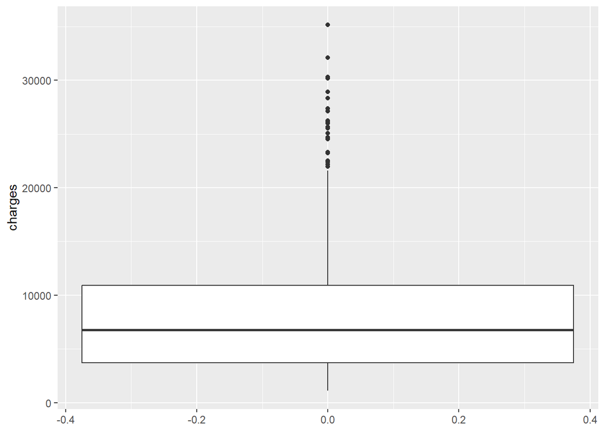

```r
df |>
  filter(smoker == "no" & bmi<30 ) |>
  ggplot(aes(y=charges)) + geom_boxplot()
```